# Optimal Treatment Analysis

## Outcome Variable

**Outcome Variable:** ever_wasted

## Predictor Variables

**Intervention Variable:** fage

**Adjustment Set:**

- arm
- W_mage
- meducyrs
- feducyrs
- W_mhtcm
- W_mwtkg
- W_mbmi
- W_fhtcm
- single
- brthmon
- delta_W_mage
- delta_meducyrs
- delta_feducyrs
- delta_W_mhtcm
- delta_W_mwtkg
- delta_W_mbmi
- delta_W_fhtcm
- delta_single
- delta_brthmon

## Stratifying Variables

The analysis was stratified on these variable(s):

- agecat
- studyid
- country

## Data Summary

| agecat | studyid | country | fage | ever_wasted | n_cell | n |
| --- | --- | --- | --- | --- | --- | --- |
| 0-24 months | ki0047075b-MAL-ED | BANGLADESH | >=38 | 0 | 46 | 151 |
| 0-24 months | ki0047075b-MAL-ED | BANGLADESH | >=38 | 1 | 23 | 151 |
| 0-24 months | ki0047075b-MAL-ED | BANGLADESH | <32 | 0 | 15 | 151 |
| 0-24 months | ki0047075b-MAL-ED | BANGLADESH | <32 | 1 | 15 | 151 |
| 0-24 months | ki0047075b-MAL-ED | BANGLADESH | [32-38) | 0 | 39 | 151 |
| 0-24 months | ki0047075b-MAL-ED | BANGLADESH | [32-38) | 1 | 13 | 151 |
| 0-24 months | ki0047075b-MAL-ED | BRAZIL | >=38 | 0 | 30 | 79 |
| 0-24 months | ki0047075b-MAL-ED | BRAZIL | >=38 | 1 | 0 | 79 |
| 0-24 months | ki0047075b-MAL-ED | BRAZIL | <32 | 0 | 16 | 79 |
| 0-24 months | ki0047075b-MAL-ED | BRAZIL | <32 | 1 | 2 | 79 |
| 0-24 months | ki0047075b-MAL-ED | BRAZIL | [32-38) | 0 | 28 | 79 |
| 0-24 months | ki0047075b-MAL-ED | BRAZIL | [32-38) | 1 | 3 | 79 |
| 0-24 months | ki0047075b-MAL-ED | INDIA | >=38 | 0 | 25 | 161 |
| 0-24 months | ki0047075b-MAL-ED | INDIA | >=38 | 1 | 11 | 161 |
| 0-24 months | ki0047075b-MAL-ED | INDIA | <32 | 0 | 20 | 161 |
| 0-24 months | ki0047075b-MAL-ED | INDIA | <32 | 1 | 33 | 161 |
| 0-24 months | ki0047075b-MAL-ED | INDIA | [32-38) | 0 | 36 | 161 |
| 0-24 months | ki0047075b-MAL-ED | INDIA | [32-38) | 1 | 36 | 161 |
| 0-24 months | ki0047075b-MAL-ED | NEPAL | >=38 | 0 | 13 | 79 |
| 0-24 months | ki0047075b-MAL-ED | NEPAL | >=38 | 1 | 4 | 79 |
| 0-24 months | ki0047075b-MAL-ED | NEPAL | <32 | 0 | 8 | 79 |
| 0-24 months | ki0047075b-MAL-ED | NEPAL | <32 | 1 | 7 | 79 |
| 0-24 months | ki0047075b-MAL-ED | NEPAL | [32-38) | 0 | 34 | 79 |
| 0-24 months | ki0047075b-MAL-ED | NEPAL | [32-38) | 1 | 13 | 79 |
| 0-24 months | ki0047075b-MAL-ED | PERU | >=38 | 0 | 26 | 85 |
| 0-24 months | ki0047075b-MAL-ED | PERU | >=38 | 1 | 1 | 85 |
| 0-24 months | ki0047075b-MAL-ED | PERU | <32 | 0 | 25 | 85 |
| 0-24 months | ki0047075b-MAL-ED | PERU | <32 | 1 | 4 | 85 |
| 0-24 months | ki0047075b-MAL-ED | PERU | [32-38) | 0 | 26 | 85 |
| 0-24 months | ki0047075b-MAL-ED | PERU | [32-38) | 1 | 3 | 85 |

[output cut: 204 more lines]

The following strata were considered:

- agecat: 0-24 months, studyid: ki0047075b-MAL-ED, country: BANGLADESH
- agecat: 0-24 months, studyid: ki0047075b-MAL-ED, country: BRAZIL
- agecat: 0-24 months, studyid: ki0047075b-MAL-ED, country: INDIA
- agecat: 0-24 months, studyid: ki0047075b-MAL-ED, country: NEPAL
- agecat: 0-24 months, studyid: ki0047075b-MAL-ED, country: PERU
- agecat: 0-24 months, studyid: ki0047075b-MAL-ED, country: SOUTH AFRICA
- agecat: 0-24 months, studyid: ki0047075b-MAL-ED, country: TANZANIA, UNITED REPUBLIC OF
- agecat: 0-24 months, studyid: ki1000304b-SAS-CompFeed, country: INDIA
- agecat: 0-24 months, studyid: ki1000304b-SAS-FoodSuppl, country: INDIA
- agecat: 0-24 months, studyid: ki1119695-PROBIT, country: BELARUS
- agecat: 0-24 months, studyid: ki1135781-COHORTS, country: GUATEMALA
- agecat: 0-24 months, studyid: ki1135781-COHORTS, country: PHILIPPINES
- agecat: 0-24 months, studyid: ki1148112-LCNI-5, country: MALAWI
- agecat: 0-6 months, studyid: ki0047075b-MAL-ED, country: BANGLADESH
- agecat: 0-6 months, studyid: ki0047075b-MAL-ED, country: BRAZIL
- agecat: 0-6 months, studyid: ki0047075b-MAL-ED, country: INDIA
- agecat: 0-6 months, studyid: ki0047075b-MAL-ED, country: NEPAL
- agecat: 0-6 months, studyid: ki0047075b-MAL-ED, country: PERU
- agecat: 0-6 months, studyid: ki0047075b-MAL-ED, country: SOUTH AFRICA
- agecat: 0-6 months, studyid: ki0047075b-MAL-ED, country: TANZANIA, UNITED REPUBLIC OF
- agecat: 0-6 months, studyid: ki1000304b-SAS-CompFeed, country: INDIA
- agecat: 0-6 months, studyid: ki1000304b-SAS-FoodSuppl, country: INDIA
- agecat: 0-6 months, studyid: ki1119695-PROBIT, country: BELARUS
- agecat: 0-6 months, studyid: ki1135781-COHORTS, country: GUATEMALA
- agecat: 0-6 months, studyid: ki1135781-COHORTS, country: PHILIPPINES
- agecat: 0-6 months, studyid: ki1148112-LCNI-5, country: MALAWI
- agecat: 6-24 months, studyid: ki0047075b-MAL-ED, country: BANGLADESH
- agecat: 6-24 months, studyid: ki0047075b-MAL-ED, country: BRAZIL
- agecat: 6-24 months, studyid: ki0047075b-MAL-ED, country: INDIA
- agecat: 6-24 months, studyid: ki0047075b-MAL-ED, country: NEPAL
- agecat: 6-24 months, studyid: ki0047075b-MAL-ED, country: PERU
- agecat: 6-24 months, studyid: ki0047075b-MAL-ED, country: SOUTH AFRICA
- agecat: 6-24 months, studyid: ki0047075b-MAL-ED, country: TANZANIA, UNITED REPUBLIC OF
- agecat: 6-24 months, studyid: ki1000304b-SAS-CompFeed, country: INDIA
- agecat: 6-24 months, studyid: ki1000304b-SAS-FoodSuppl, country: INDIA
- agecat: 6-24 months, studyid: ki1119695-PROBIT, country: BELARUS
- agecat: 6-24 months, studyid: ki1135781-COHORTS, country: GUATEMALA
- agecat: 6-24 months, studyid: ki1135781-COHORTS, country: PHILIPPINES
- agecat: 6-24 months, studyid: ki1148112-LCNI-5, country: MALAWI

### Dropped Strata

Some strata were dropped due to rare outcomes:

- agecat: 0-24 months, studyid: ki0047075b-MAL-ED, country: BRAZIL
- agecat: 0-24 months, studyid: ki0047075b-MAL-ED, country: NEPAL
- agecat: 0-24 months, studyid: ki0047075b-MAL-ED, country: PERU
- agecat: 0-24 months, studyid: ki0047075b-MAL-ED, country: SOUTH AFRICA
- agecat: 0-24 months, studyid: ki0047075b-MAL-ED, country: TANZANIA, UNITED REPUBLIC OF
- agecat: 0-24 months, studyid: ki1000304b-SAS-CompFeed, country: INDIA
- agecat: 0-24 months, studyid: ki1148112-LCNI-5, country: MALAWI
- agecat: 0-6 months, studyid: ki0047075b-MAL-ED, country: BRAZIL
- agecat: 0-6 months, studyid: ki0047075b-MAL-ED, country: NEPAL
- agecat: 0-6 months, studyid: ki0047075b-MAL-ED, country: PERU
- agecat: 0-6 months, studyid: ki0047075b-MAL-ED, country: SOUTH AFRICA
- agecat: 0-6 months, studyid: ki0047075b-MAL-ED, country: TANZANIA, UNITED REPUBLIC OF
- agecat: 0-6 months, studyid: ki1000304b-SAS-CompFeed, country: INDIA
- agecat: 0-6 months, studyid: ki1000304b-SAS-FoodSuppl, country: INDIA
- agecat: 0-6 months, studyid: ki1148112-LCNI-5, country: MALAWI
- agecat: 6-24 months, studyid: ki0047075b-MAL-ED, country: BRAZIL
- agecat: 6-24 months, studyid: ki0047075b-MAL-ED, country: NEPAL
- agecat: 6-24 months, studyid: ki0047075b-MAL-ED, country: PERU
- agecat: 6-24 months, studyid: ki0047075b-MAL-ED, country: SOUTH AFRICA
- agecat: 6-24 months, studyid: ki0047075b-MAL-ED, country: TANZANIA, UNITED REPUBLIC OF
- agecat: 6-24 months, studyid: ki1000304b-SAS-CompFeed, country: INDIA
- agecat: 6-24 months, studyid: ki1000304b-SAS-FoodSuppl, country: INDIA
- agecat: 6-24 months, studyid: ki1119695-PROBIT, country: BELARUS
- agecat: 6-24 months, studyid: ki1148112-LCNI-5, country: MALAWI

## Methods Detail

We’re interested in the causal parameters $E[Y_a]$ for all values of $a \in \mathcal{A}$. These parameters represent the mean outcome if, possibly contrary to fact, we intervened to set all units to have $A=a$. Under the randomization and positivity assumptions, these are identified by the statistical parameters $\psi_a=E_W[E_{Y|A,W}(Y|A=a,W)]$. In addition, we’re interested in the mean of $Y$, $E[Y]$ under no intervention (the observed mean). We will estimate these parameters by using SuperLearner to fit the relevant likelihood factors – $E_{Y|A,W}(Y|A=a,W)$ and $p(A=a|W)$, and then updating our likelihood fit using a joint TMLE.

For unadjusted analyses ($W=\{\}$), initial likelihoods were estimated using Lrnr_glm to estimate the simple $E(Y|A)$ and Lrnr_mean to estimate $p(A)$. For adjusted analyses, a small library containing Lrnr_glmnet, Lrnr_xgboost, and Lrnr_mean was used.

Having estimated these parameters, we will then use the delta method to estimate relative risks and attributable risks relative to a prespecified baseline level of $A$.

# Results Detail

## Results Plots

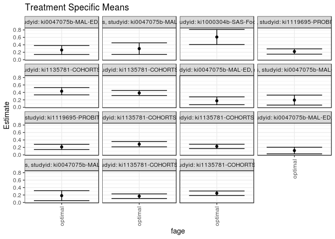

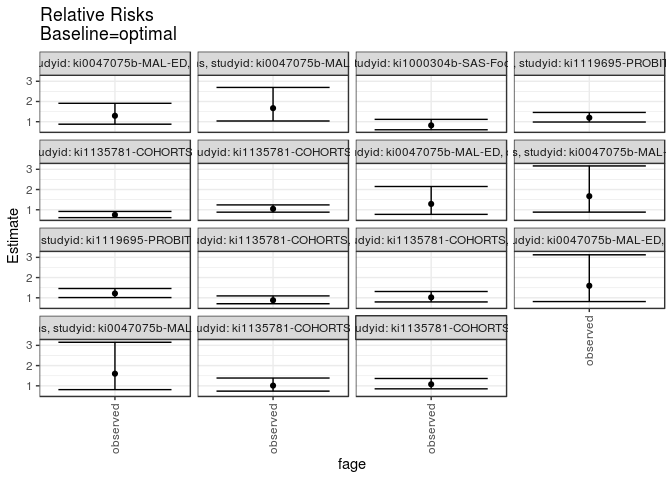

## Results Table

### Parameter: TSM

| agecat | studyid | country | intervention_level | baseline_level | estimate | ci_lower | ci_upper |
| --- | --- | --- | --- | --- | --- | --- | --- |
| 0-24 months | ki0047075b-MAL-ED | BANGLADESH | optimal | NA | 0.2609611 | 0.1405010 | 0.3814211 |
| 0-24 months | ki0047075b-MAL-ED | INDIA | optimal | NA | 0.2974266 | 0.1413977 | 0.4534554 |
| 0-24 months | ki1000304b-SAS-FoodSuppl | INDIA | optimal | NA | 0.6094553 | 0.4073215 | 0.8115891 |
| 0-24 months | ki1119695-PROBIT | BELARUS | optimal | NA | 0.2207521 | 0.1505465 | 0.2909578 |
| 0-24 months | ki1135781-COHORTS | GUATEMALA | optimal | NA | 0.4321022 | 0.3340041 | 0.5302002 |
| 0-24 months | ki1135781-COHORTS | PHILIPPINES | optimal | NA | 0.3844185 | 0.3161119 | 0.4527252 |
| 0-6 months | ki0047075b-MAL-ED | BANGLADESH | optimal | NA | 0.1747288 | 0.0693527 | 0.2801049 |
| 0-6 months | ki0047075b-MAL-ED | INDIA | optimal | NA | 0.1932292 | 0.0590513 | 0.3274070 |
| 0-6 months | ki1119695-PROBIT | BELARUS | optimal | NA | 0.2130564 | 0.1422598 | 0.2838530 |
| 0-6 months | ki1135781-COHORTS | GUATEMALA | optimal | NA | 0.2861170 | 0.2154351 | 0.3567989 |
| 0-6 months | ki1135781-COHORTS | PHILIPPINES | optimal | NA | 0.2273400 | 0.1687891 | 0.2858910 |
| 6-24 months | ki0047075b-MAL-ED | BANGLADESH | optimal | NA | 0.1162586 | 0.0271964 | 0.2053209 |
| 6-24 months | ki0047075b-MAL-ED | INDIA | optimal | NA | 0.1823138 | 0.0484666 | 0.3161610 |
| 6-24 months | ki1135781-COHORTS | GUATEMALA | optimal | NA | 0.1673981 | 0.1055365 | 0.2292597 |
| 6-24 months | ki1135781-COHORTS | PHILIPPINES | optimal | NA | 0.2470669 | 0.1866157 | 0.3075180 |

### Parameter: E(Y)

| agecat | studyid | country | intervention_level | baseline_level | estimate | ci_lower | ci_upper |
| --- | --- | --- | --- | --- | --- | --- | --- |
| 0-24 months | ki0047075b-MAL-ED | BANGLADESH | observed | NA | 0.3377483 | 0.2620632 | 0.4134335 |
| 0-24 months | ki0047075b-MAL-ED | INDIA | observed | NA | 0.4968944 | 0.4194215 | 0.5743673 |
| 0-24 months | ki1000304b-SAS-FoodSuppl | INDIA | observed | NA | 0.5000000 | 0.4043636 | 0.5956364 |
| 0-24 months | ki1119695-PROBIT | BELARUS | observed | NA | 0.2645591 | 0.1704386 | 0.3586795 |
| 0-24 months | ki1135781-COHORTS | GUATEMALA | observed | NA | 0.3231511 | 0.2863678 | 0.3599345 |
| 0-24 months | ki1135781-COHORTS | PHILIPPINES | observed | NA | 0.4018374 | 0.3841095 | 0.4195652 |
| 0-6 months | ki0047075b-MAL-ED | BANGLADESH | observed | NA | 0.2251656 | 0.1583223 | 0.2920089 |
| 0-6 months | ki0047075b-MAL-ED | INDIA | observed | NA | 0.3229814 | 0.2505249 | 0.3954378 |
| 0-6 months | ki1119695-PROBIT | BELARUS | observed | NA | 0.2588326 | 0.1637240 | 0.3539411 |
| 0-6 months | ki1135781-COHORTS | GUATEMALA | observed | NA | 0.2515337 | 0.2130371 | 0.2900303 |
| 0-6 months | ki1135781-COHORTS | PHILIPPINES | observed | NA | 0.2321307 | 0.2168619 | 0.2473995 |
| 6-24 months | ki0047075b-MAL-ED | BANGLADESH | observed | NA | 0.1854305 | 0.1232352 | 0.2476257 |
| 6-24 months | ki0047075b-MAL-ED | INDIA | observed | NA | 0.2919255 | 0.2214783 | 0.3623726 |
| 6-24 months | ki1135781-COHORTS | GUATEMALA | observed | NA | 0.1693122 | 0.1384161 | 0.2002082 |
| 6-24 months | ki1135781-COHORTS | PHILIPPINES | observed | NA | 0.2661765 | 0.2495644 | 0.2827886 |

### Parameter: RR

| agecat | studyid | country | intervention_level | baseline_level | estimate | ci_lower | ci_upper |
| --- | --- | --- | --- | --- | --- | --- | --- |
| 0-24 months | ki0047075b-MAL-ED | BANGLADESH | observed | optimal | 1.2942481 | 0.8769352 | 1.9101502 |
| 0-24 months | ki0047075b-MAL-ED | INDIA | observed | optimal | 1.6706457 | 1.0355939 | 2.6951269 |
| 0-24 months | ki1000304b-SAS-FoodSuppl | INDIA | observed | optimal | 0.8204047 | 0.6024075 | 1.1172899 |
| 0-24 months | ki1119695-PROBIT | BELARUS | observed | optimal | 1.1984441 | 0.9845214 | 1.4588493 |
| 0-24 months | ki1135781-COHORTS | GUATEMALA | observed | optimal | 0.7478582 | 0.6095344 | 0.9175722 |
| 0-24 months | ki1135781-COHORTS | PHILIPPINES | observed | optimal | 1.0453121 | 0.8808392 | 1.2404959 |
| 0-6 months | ki0047075b-MAL-ED | BANGLADESH | observed | optimal | 1.2886576 | 0.7720483 | 2.1509515 |
| 0-6 months | ki0047075b-MAL-ED | INDIA | observed | optimal | 1.6714939 | 0.8822878 | 3.1666447 |
| 0-6 months | ki1119695-PROBIT | BELARUS | observed | optimal | 1.2148546 | 1.0111466 | 1.4596022 |
| 0-6 months | ki1135781-COHORTS | GUATEMALA | observed | optimal | 0.8791291 | 0.7069300 | 1.0932737 |
| 0-6 months | ki1135781-COHORTS | PHILIPPINES | observed | optimal | 1.0210728 | 0.7951272 | 1.3112236 |
| 6-24 months | ki0047075b-MAL-ED | BANGLADESH | observed | optimal | 1.5949825 | 0.8137779 | 3.1261222 |
| 6-24 months | ki0047075b-MAL-ED | INDIA | observed | optimal | 1.6012254 | 0.8127290 | 3.1547079 |
| 6-24 months | ki1135781-COHORTS | GUATEMALA | observed | optimal | 1.0114342 | 0.7376919 | 1.3867566 |
| 6-24 months | ki1135781-COHORTS | PHILIPPINES | observed | optimal | 1.0773459 | 0.8518020 | 1.3626103 |

### Parameter: PAR

| agecat | studyid | country | intervention_level | baseline_level | estimate | ci_lower | ci_upper |
| --- | --- | --- | --- | --- | --- | --- | --- |
| 0-24 months | ki0047075b-MAL-ED | BANGLADESH | optimal | NA | 0.0767873 | -0.0251303 | 0.1787048 |
| 0-24 months | ki0047075b-MAL-ED | INDIA | optimal | NA | 0.1994678 | 0.0584597 | 0.3404760 |
| 0-24 months | ki1000304b-SAS-FoodSuppl | INDIA | optimal | NA | -0.1094553 | -0.2949431 | 0.0760324 |
| 0-24 months | ki1119695-PROBIT | BELARUS | optimal | NA | 0.0438070 | -0.0086014 | 0.0962153 |
| 0-24 months | ki1135781-COHORTS | GUATEMALA | optimal | NA | -0.1089510 | -0.1973298 | -0.0205722 |
| 0-24 months | ki1135781-COHORTS | PHILIPPINES | optimal | NA | 0.0174188 | -0.0483802 | 0.0832179 |
| 0-6 months | ki0047075b-MAL-ED | BANGLADESH | optimal | NA | 0.0504368 | -0.0396826 | 0.1405562 |
| 0-6 months | ki0047075b-MAL-ED | INDIA | optimal | NA | 0.1297522 | 0.0052566 | 0.2542478 |
| 0-6 months | ki1119695-PROBIT | BELARUS | optimal | NA | 0.0457762 | -0.0030150 | 0.0945673 |
| 0-6 months | ki1135781-COHORTS | GUATEMALA | optimal | NA | -0.0345832 | -0.0963920 | 0.0272255 |
| 0-6 months | ki1135781-COHORTS | PHILIPPINES | optimal | NA | 0.0047907 | -0.0520748 | 0.0616561 |
| 6-24 months | ki0047075b-MAL-ED | BANGLADESH | optimal | NA | 0.0691718 | -0.0113621 | 0.1497058 |
| 6-24 months | ki0047075b-MAL-ED | INDIA | optimal | NA | 0.1096117 | -0.0151557 | 0.2343790 |
| 6-24 months | ki1135781-COHORTS | GUATEMALA | optimal | NA | 0.0019141 | -0.0509066 | 0.0547347 |
| 6-24 months | ki1135781-COHORTS | PHILIPPINES | optimal | NA | 0.0191096 | -0.0389069 | 0.0771261 |

### Parameter: PAF

| agecat | studyid | country | intervention_level | baseline_level | estimate | ci_lower | ci_upper |
| --- | --- | --- | --- | --- | --- | --- | --- |
| 0-24 months | ki0047075b-MAL-ED | BANGLADESH | optimal | NA | 0.2273506 | -0.1403351 | 0.4764810 |
| 0-24 months | ki0047075b-MAL-ED | INDIA | optimal | NA | 0.4014290 | 0.0343705 | 0.6289600 |
| 0-24 months | ki1000304b-SAS-FoodSuppl | INDIA | optimal | NA | -0.2189107 | -0.6600059 | 0.1049771 |
| 0-24 months | ki1119695-PROBIT | BELARUS | optimal | NA | 0.1655848 | -0.0157219 | 0.3145282 |
| 0-24 months | ki1135781-COHORTS | GUATEMALA | optimal | NA | -0.3371519 | -0.6405964 | -0.0898325 |
| 0-24 months | ki1135781-COHORTS | PHILIPPINES | optimal | NA | 0.0433480 | -0.1352809 | 0.1938708 |
| 0-6 months | ki0047075b-MAL-ED | BANGLADESH | optimal | NA | 0.2239987 | -0.2952557 | 0.5350895 |
| 0-6 months | ki0047075b-MAL-ED | INDIA | optimal | NA | 0.4017328 | -0.1334170 | 0.6842083 |
| 0-6 months | ki1119695-PROBIT | BELARUS | optimal | NA | 0.1768562 | 0.0110237 | 0.3148818 |
| 0-6 months | ki1135781-COHORTS | GUATEMALA | optimal | NA | -0.1374894 | -0.4145673 | 0.0853160 |
| 0-6 months | ki1135781-COHORTS | PHILIPPINES | optimal | NA | 0.0206379 | -0.2576604 | 0.2373536 |
| 6-24 months | ki0047075b-MAL-ED | BANGLADESH | optimal | NA | 0.3730339 | -0.2288365 | 0.6801149 |
| 6-24 months | ki0047075b-MAL-ED | INDIA | optimal | NA | 0.3754783 | -0.2304224 | 0.6830134 |
| 6-24 months | ki1135781-COHORTS | GUATEMALA | optimal | NA | 0.0113049 | -0.3555795 | 0.2788929 |
| 6-24 months | ki1135781-COHORTS | PHILIPPINES | optimal | NA | 0.0717930 | -0.1739818 | 0.2661145 |